# Malaria Cells Detection Using Neural Network

Malaria is a life threatening disease that is spread by mosquitoes. The disease mainly impacts tropical and subtropical

regions. Glovally there are a total of 229 million cases and 409000 cases worldwide. This makes it crucial to for early

detection systems for Plasmodium infected cells. This has brought an important discussion in the data realm on the use of

neural networks to automate cell detection and classification. This would greatly enhance the fight against malaria as it would

increase the speed and accuracy of malaria diagnosis thus improving public health worldwide.

# Problem Statement

Malaria is a significant health problem glovally and it impacts millions of people worldwide. The technological advancement in

the current era and the emergence of artificial intelligence has raised the important question on the creating a system that

can timely and accurately diagnosis the disease in order to increase effectiveness in treatement and in the management of the

disease. The traditional detection system involved manually checking examining the blood samples using microscopes in order to

detect the Plasmodium infected cells. This was a labor intensive process that was often done by well trained and experienced

tetechnicians. However, this posed a problem of human error and also limited resources since getting well trained and

experienced Technicians was time consuming and difficult.This report aims to provide a comprehensive model that would provide a

solution to this critical problem.

# Methodology

The proposed methodology for the malaria cell detections system using neural networks involved multi step process. The

methodolodgy involved loading the necessary python libraries suchs as Numpy,Pandas,Matplotlib, Scikit-learn, TensorFlow and

TensorFlow Datasets which were imported in order to facilitate data preporcessing, model development and evaluation.The image

data was preporcessed by resizing the images to consistent size then it was input into a neural network mode.The model

framework was constructed using the Kera Sequential API and Tensorflow. The model consists of different techniques such as

convolutional, pooling,dense layers and droput with the last layer using the sigmoid activation function for the binary

calssification. This model is vary effective in capturing the eminent featurs of the Plasmodium-infected cells and accurately

being able to differentiate them from healthy cells.

## Loading the Required Packages

The Packages were loaded into python environment using the code below:

```python
# Loading the tensorflow packages to be used in loading the data
import re
import os
import numpy as np
import pandas as pd
import matplotlib.pyplot as plt
from sklearn.model_selection import train_test_split
import tensorflow as tf
import tensorflow_datasets as tfds
```

## Loading the Data into Python

The dataset used for the study below was obtained for Tensorflow dataset and was ingested using the tfds.load(). The train

split was used to retreive teh training data.The shuffle parameter was supposed to make sure that the files were shuffled

before being loaded.

```python
# Loading the Malaria data

malaria, info = tfds.load('malaria', split='train', shuffle_files=True, with_info=True)
```

```python
# getting the dataset info
info
```

```
tfds.core.DatasetInfo(
    name='malaria',
    full_name='malaria/1.0.0',
    description="""
    The Malaria dataset contains a total of 27,558 cell images with equal instances
    of parasitized and uninfected cells from the thin blood smear slide images of
    segmented cells.
    """,
    homepage='https://lhncbc.nlm.nih.gov/publication/pub9932',
    data_dir='C:\\Users\\Fredrick.Muchoya\\tensorflow_datasets\\malaria\\1.0.0',
    file_format=tfrecord,
    download_size=337.08 MiB,
    dataset_size=317.62 MiB,
    features=FeaturesDict({
        'image': Image(shape=(None, None, 3), dtype=uint8),
        'label': ClassLabel(shape=(), dtype=int64, num_classes=2),
    }),
    supervised_keys=('image', 'label'),
    disable_shuffling=False,
    splits={
        'train': <SplitInfo num_examples=27558, num_shards=4>,
    },
    citation="""@article{rajaraman2018pre,
      title={Pre-trained convolutional neural networks as feature extractors toward
      improved malaria parasite detection in thin blood smear images},
      author={Rajaraman, Sivaramakrishnan and Antani, Sameer K and Poostchi, Mahdieh
      and Silamut, Kamolrat and Hossain, Md A and Maude, Richard J and Jaeger,
      Stefan and Thoma, George R},
      journal={PeerJ},
      volume={6},
      pages={e4568},
      year={2018},
      publisher={PeerJ Inc.}
    }""",
)
```

```python
# Checking the two different classes of images that we have

print('Num classes: ' + str(info.features['label'].num_classes))
print("Class names: " + str(info.features['label'].names))
```

```
Num classes: 2
Class names: ['parasitized', 'uninfected']
```

## Visualizing the Malaria Dataset

This section will focus on visualizing the malaria dataset. This will help in providing visual insights of the data.

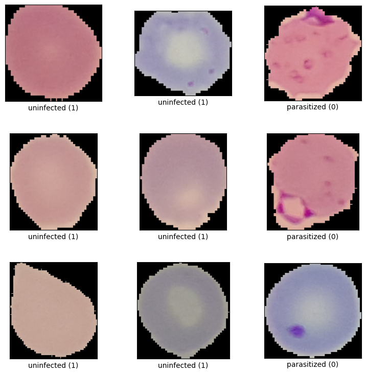

```python
# Visualizing the dataset

malaria_vis=tfds.visualization.show_examples(malaria,info)
```

## Feature Extraction

The section conducts feature extraction of the data.This step ensures that the image data and their associated labels are

properly stored in separate lists, preparing the data for the subsequent model training and evaluation stages. The feature

extraction process is a crucial step in the overall methodology, as it transforms the raw dataset into a format that can be

effectively utilized by the neural network model for the malaria cell detection task.

```python
# Feature Extraction
train_images = []
train_labels = []

for images in malaria:
    train_images.append(images['image'].numpy())
    train_labels.append(images['label'].numpy())
```

```python
import cv2

train_images = []
train_labels = []

for images in malaria:
    image = images['image'].numpy()
    image = cv2.resize(image, (224, 224))  # Resize the image to 224x224
    train_images.append(image)
    train_labels.append(images['label'].numpy())

train_images = np.array(train_images)
train_labels = np.array(train_labels)
```

```python
print("Image:")
print(train_images[0])
print("Label: " + str(train_labels[0]))
```

[output not shown]

## Building the Model

The data for the malaria cell detection model was loaded from the 'malaria' dataset provided by TensorFlow Datasets (TFDS). The

dataset was split into training, validation, and test sets using the tfds.load() function with the split parameter. The

training set consisted of 70% of the data, the validation set contained 15% of the data, and the remaining 15% was used for the

test set. The shuffle_files=True parameter was used to ensure that the files were shuffled before being loaded, and the

as_supervised=True parameter was set to indicate that the dataset contains both input features (images) and labels. The size of

the input images was set to 200x200 pixels, and the batch size was set to 32. Finally, the number of images in each of the

training, validation, and test sets was printed to provide an overview of the dataset used in the malaria cell detection model.

```python
# Building the model
BATCH_SIZE = 32
IMAGE_SIZE = [200, 200]

train_malaria, val_malaria, test_malaria = tfds.load('malaria',
                                      split=['train[:70%]', 'train[70%:85%]', 'train[85%:]'],
                                      shuffle_files=True, as_supervised=True)
```

```python
NUM_TRAIN_IMAGES = tf.data.experimental.cardinality(train_malaria).numpy()
print("Num training images: " + str(NUM_TRAIN_IMAGES))

NUM_VAL_IMAGES = tf.data.experimental.cardinality(val_malaria).numpy()
print("Num validating images: " + str(NUM_VAL_IMAGES))

NUM_TEST_IMAGES = tf.data.experimental.cardinality(test_malaria).numpy()
print("Num testing images: " + str(NUM_TEST_IMAGES))
```

```
Num training images: 19291
Num validating images: 4133
Num testing images: 4134
```

```python
for image, label in train_malaria.take(1):
    print("Image shape: ", image.numpy().shape)
    print("Label: ", label.numpy())
```

```
Image shape:  (103, 103, 3)
Label:  1
```

## Resizing Big Pictures

computational efficiency.

```python
# Resizing Big Pictures
def convert(image, label):
  image = tf.image.convert_image_dtype(image, tf.float32)
  return image, label

def pad(image,label):
  image,label = convert(image, label)
  image = tf.image.resize_with_crop_or_pad(image, 200, 200)
  return image,label
```

```python
padded_train_malaria = (
    train_malaria
    .cache()
    .map(pad)
    .batch(BATCH_SIZE)
)

padded_val_malaria = (
    val_ds
    .cache()
    .map(pad)
    .batch(BATCH_SIZE)
)
```

```python
image_batch, label_batch = next(iter(padded_train_malaria))

def show_batch(image_batch, label_batch):
    plt.figure(figsize=(10,10))
    for n in range(25):
        ax = plt.subplot(5,5,n+1)
        plt.imshow(image_batch[n])
        if label_batch[n]:
            plt.title("uninfected")
        else:
            plt.title("parasitized")
        plt.axis("off")
```

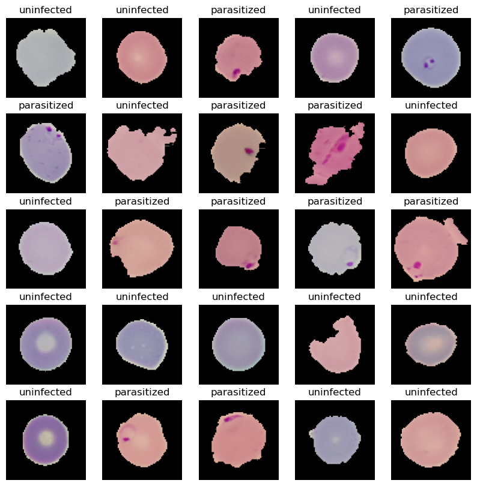

```python
show_batch(image_batch.numpy(), label_batch.numpy())
```

## Building the Model

channels. The model starts with two convolutional layers, each with 16 filters and a 3x3 kernel size, followed by a ReLU

activation function and same padding to preserve the spatial dimensions. A max-pooling layer is then applied to downsample the

feature maps. This is followed by a series of custom conv_block and dense_block functions, which encapsulate the convolutional

and dense layers, respectively. The convolutional blocks progressively increase the number of filters, while the dense blocks

reduce the dimensionality of the features and apply dropout to prevent overfitting. Finally, a single dense layer with a

sigmoid activation function is used for the binary classification of malaria-infected and healthy cells. The model is compiled

with the Adam optimizer and binary cross-entropy loss, with the Area Under the Curve (AUC) metric used to evaluate the model's

performance.

```python
# Building the Model

def conv_block(filters):
    block = tf.keras.Sequential([
        tf.keras.layers.SeparableConv2D(filters, 3, activation='relu', padding='same'),
        tf.keras.layers.SeparableConv2D(filters, 3, activation='relu', padding='same'),
        tf.keras.layers.BatchNormalization(),
        tf.keras.layers.MaxPool2D()
    ]
    )

    return block

def dense_block(units, dropout_rate):
    block = tf.keras.Sequential([
        tf.keras.layers.Dense(units, activation='relu'),
        tf.keras.layers.BatchNormalization(),
        tf.keras.layers.Dropout(dropout_rate)
    ])

    return block
```

```python
def build_model():
    model = tf.keras.Sequential([
        tf.keras.Input(shape=(IMAGE_SIZE[0], IMAGE_SIZE[1], 3)),

        tf.keras.layers.Conv2D(16, 3, activation='relu', padding='same'),
        tf.keras.layers.Conv2D(16, 3, activation='relu', padding='same'),
        tf.keras.layers.MaxPool2D(),

        conv_block(32),
        conv_block(64),

        conv_block(128),
        tf.keras.layers.Dropout(0.2),

        conv_block(256),
        tf.keras.layers.Dropout(0.2),

        tf.keras.layers.Flatten(),
        dense_block(512, 0.7),
        dense_block(128, 0.5),
        dense_block(64, 0.3),

        tf.keras.layers.Dense(1, activation='sigmoid')
    ])

    return model
```

```python
model = build_model()

model.compile(
    optimizer='adam',
    loss='binary_crossentropy',
    metrics=[tf.keras.metrics.AUC(name='auc')]
)
```

```python
# Defining Callbacks
checkpoint_cb = tf.keras.callbacks.ModelCheckpoint("malaria_model.keras",
                                                  save_best_only=True)

early_stopping_cb = tf.keras.callbacks.EarlyStopping(patience=5,
                                                    restore_best_weights=True)

def exponential_decay(lr0, s):
    def exponential_decay_fn(epoch):
        return lr0 * 0.1 **(epoch / s)
    return exponential_decay_fn

exponential_decay_fn = exponential_decay(0.01, 20)

lr_scheduler = tf.keras.callbacks.LearningRateScheduler(exponential_decay_fn)
```

## Training the Model

The neural network model for malaria cell detection was trained using the model.fit() function, which takes the training

the progress displayed in the console. During each epoch, the model's performance was evaluated on both the training and

validation sets, with the Area Under the Curve (AUC) and loss metrics being reported. The training progress shows that the

to the training data, and additional techniques, such as regularization or data augmentation, may be necessary to improve its

generalization capabilities.

```python
# Training the model
history = model.fit(
    padded_train_malaria, epochs=20,
    validation_data=padded_val_malaria,
    callbacks=[checkpoint_cb, early_stopping_cb, lr_scheduler]
)
```

```
603/603 ━━━━━━━━━━━━━━━━━━━━ 56s 90ms/step - auc: 0.4200 - loss: 1.1314 - val_auc: 0.5000 - val_loss: 0.8670 - learning_rate: 0.0100
603/603 ━━━━━━━━━━━━━━━━━━━━ 62s 98ms/step - auc: 0.5687 - loss: 1.0794 - val_auc: 0.5000 - val_loss: 0.8732 - learning_rate: 0.0089
603/603 ━━━━━━━━━━━━━━━━━━━━ 52s 84ms/step - auc: 0.7676 - loss: 0.6478 - val_auc: 0.5000 - val_loss: 0.9073 - learning_rate: 0.0079
603/603 ━━━━━━━━━━━━━━━━━━━━ 50s 81ms/step - auc: 0.6213 - loss: 0.7297 - val_auc: 0.5000 - val_loss: 0.8036 - learning_rate: 0.0071
603/603 ━━━━━━━━━━━━━━━━━━━━ 52s 83ms/step - auc: 0.6825 - loss: 0.6901 - val_auc: 0.5000 - val_loss: 0.8246 - learning_rate: 0.0063
603/603 ━━━━━━━━━━━━━━━━━━━━ 48s 78ms/step - auc: 0.7651 - loss: 0.6589 - val_auc: 0.5000 - val_loss: 0.9155 - learning_rate: 0.0056
603/603 ━━━━━━━━━━━━━━━━━━━━ 51s 82ms/step - auc: 0.7700 - loss: 0.6104 - val_auc: 0.5000 - val_loss: 0.9701 - learning_rate: 0.0050
603/603 ━━━━━━━━━━━━━━━━━━━━ 49s 80ms/step - auc: 0.7149 - loss: 0.6555 - val_auc: 0.5007 - val_loss: 0.9996 - learning_rate: 0.0045
603/603 ━━━━━━━━━━━━━━━━━━━━ 59s 95ms/step - auc: 0.7925 - loss: 0.5268 - val_auc: 0.5325 - val_loss: 0.9837 - learning_rate: 0.0040
```

## Model Perfomance

After training the model, its performance was evaluated on the test dataset. The test dataset was first preprocessed by padding

the images to the required size, and then the model was evaluated using the model.evaluate() function. The evaluation results

showed that the model achieved an AUC (Area Under the Curve) score of 0.5 and a loss of 0.8262 on the test set. This indicates

that the model's performance on the unseen test data was not particularly strong, suggesting that the model may be overfitting

to the training data or that the training dataset was not diverse enough to generalize well.

```python
# Evaluating Model Perfomance
padded_test_malaria = (
     test_malaria
    .cache()
    .map(pad)
    .batch(BATCH_SIZE)
)
```

```python
model.evaluate(padded_test_malaria)
```

```
130/130 ━━━━━━━━━━━━━━━━━━━━ 47s 355ms/step - auc: 0.5000 - loss: 0.8262
```

```
[0.8115347623825073, 0.5]
```

```python
model.summary()
```

```
Model: "sequential_7"
```

```
┏━━━━━━━━━━━━━━━━━━━━━━━━━━━━━━━━━━━━━━┳━━━━━━━━━━━━━━━━━━━━━━━━━━━━━┳━━━━━━━━━━━━━━━━━┓
┃ Layer (type)                         ┃ Output Shape                ┃         Param # ┃
┡━━━━━━━━━━━━━━━━━━━━━━━━━━━━━━━━━━━━━━╇━━━━━━━━━━━━━━━━━━━━━━━━━━━━━╇━━━━━━━━━━━━━━━━━┩
│ conv2d (Conv2D)                      │ (None, 200, 200, 16)        │             448 │
├──────────────────────────────────────┼─────────────────────────────┼─────────────────┤
│ conv2d_1 (Conv2D)                    │ (None, 200, 200, 16)        │           2,320 │
├──────────────────────────────────────┼─────────────────────────────┼─────────────────┤
│ max_pooling2d (MaxPooling2D)         │ (None, 100, 100, 16)        │               0 │
├──────────────────────────────────────┼─────────────────────────────┼─────────────────┤
│ sequential (Sequential)              │ (None, 50, 50, 32)          │           2,160 │
├──────────────────────────────────────┼─────────────────────────────┼─────────────────┤
│ sequential_1 (Sequential)            │ (None, 25, 25, 64)          │           7,392 │
├──────────────────────────────────────┼─────────────────────────────┼─────────────────┤
│ sequential_2 (Sequential)            │ (None, 12, 12, 128)         │          27,072 │
├──────────────────────────────────────┼─────────────────────────────┼─────────────────┤
│ dropout (Dropout)                    │ (None, 12, 12, 128)         │               0 │
├──────────────────────────────────────┼─────────────────────────────┼─────────────────┤
│ sequential_3 (Sequential)            │ (None, 6, 6, 256)           │         103,296 │
├──────────────────────────────────────┼─────────────────────────────┼─────────────────┤
│ dropout_1 (Dropout)                  │ (None, 6, 6, 256)           │               0 │
├──────────────────────────────────────┼─────────────────────────────┼─────────────────┤
│ flatten (Flatten)                    │ (None, 9216)                │               0 │
├──────────────────────────────────────┼─────────────────────────────┼─────────────────┤
│ sequential_4 (Sequential)            │ (None, 512)                 │       4,721,152 │
├──────────────────────────────────────┼─────────────────────────────┼─────────────────┤
│ sequential_5 (Sequential)            │ (None, 128)                 │          66,176 │
├──────────────────────────────────────┼─────────────────────────────┼─────────────────┤
│ sequential_6 (Sequential)            │ (None, 64)                  │           8,512 │
├──────────────────────────────────────┼─────────────────────────────┼─────────────────┤
│ dense_3 (Dense)                      │ (None, 1)                   │              65 │
└──────────────────────────────────────┴─────────────────────────────┴─────────────────┘
```

```
 Total params: 14,811,045 (56.50 MB)
```

```
 Trainable params: 4,936,225 (18.83 MB)
```

```
 Non-trainable params: 2,368 (9.25 KB)
```

```
 Optimizer params: 9,872,452 (37.66 MB)
```

## Conclusion

its evaluation on the test set reveals limitations in its ability to generalize to new, unseen data. To improve the model's

performance, further investigation is needed to address potential issues such as overfitting, data imbalance, or the need for

more robust feature extraction techniques. Exploring alternative model architectures, incorporating advanced regularization

methods, and expanding the diversity of the training dataset may help enhance the model's overall accuracy and real-world

applicability for the malaria cell detection task.